# Chapter 2 Solutions

Dilan Fernando

2019-02-12

**Conceptual Questions**

## 2.4.1

Let $n$ = sample size and $p$ = number of predictors.

1. $n$ is extremely large and $p$ is small

   *Answer*: Flexible is better because we have a lot of training data and an inflexible model will have too much bias that can’t be overcome with the large amount of data points we have.
2. $p$ is extremely large and $n$ is small.

   *Answer*: An inflexible model will do better because we don’t have a lot of data (n) to work with. The flexible model will introduce large amount of variance to the model and will overfit the data.
3. The predictor response relationship is highly non-linear.

   *Answer*: The flexible method will do better because it can potentially capture all of the subtleties and non linearities in the data. An inflexible model simply won’t have the necessary number of variable to catch the non linearities.
4. The variance of the error terms $\sigma^2 = \mathrm{Var}(\epsilon)$ is extremely high.

   *Answer:* Inflexible methods are preferred. If we used flexible methods we will simply model the noise in the data and overfit our model.

## 2.4.2

1. Regression. Interested in inference. $n = 500$ and $p = 3$
2. Classification. Prediction. n = 20 and p = 13.
3. Regression. Prediction. n = 52 * 3 and p = 3.

## 2.4.3 (Bias vs Variance decomposition)

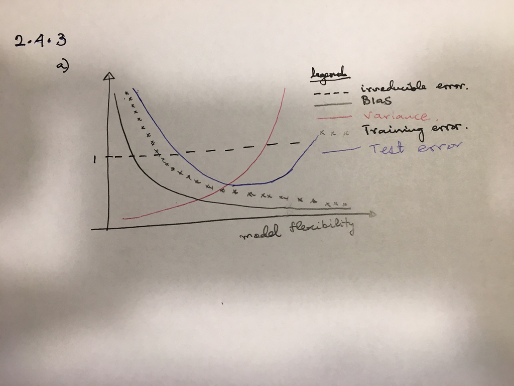

- `variance`

As model flexibility increases it starts go after (using Hastie vernacular) noise in the data. This results in an overfitting model. So if we estimate $\hat f$ using a different training set we will end up with a different $\hat f$ resulting in a higher `variance`.

- squared `bias`

Bias is introduced when we estimate a potentially complicated real- life problem using a much simpler model. So simple models will have higher bias. Naturally, as model flexibility increase this bias will decrease.

- `training error`

The more flexible the model the less the training error should be. It gradually decreases as it gradually does better and better at even predicting noise in the data.

- `test error`

Test error will decrease as model complexity increase only upto a certain point. After this point, certain models which are overfitting the data will not be able to give good predictions to unseen data resulting in a larger test error.

- `irreducible error`

Irreducible error by definition is unaffected by model flexibility (or any other external force). It remains constant no matter what.

## 2.4.4

1. **Classification examples**
   - flagging a financial transaction as fraudulent or not. This is a classification prediction problem.
   - flagging a loan application as being at risk for default or not. The end goal is prediction.
   - Trying to understand which demographic/personal data contribute to determining possible loan defaulters. This is a classification problem with the end goal of inference.
2. ** Regression **
   - Trying to predict next years sales using this years budget on advertising. This is a prediction.
   - Trying to understand which media (radio/tv/newspaper) contribute to sales. This is a regression problem whose end goal is inference.
   - Trying to predict the price of a stock using past data. The goal is prediction using regression. (of course this is a naive example).
3. **Cluster Analysis**
   - Market segmentation of identifying types of customers.
   - Determining terrorist threat levels (low, moderate, high) using NLP.
   - Segmenting a population as being at high risk, low risk and moderate for heart desease on demographic and personal data.

## 2.4.5

**More flexible vs less flexible**

A very flexible approach may be useful if we have a large number of training data (in the thousands) with only a handful of predictor variables. The reason being, with the large number of training data we will be able to capture all of the subtleties of the data set without overfitting. This of course works under the standing assumptions that the `real relationship is not linear`. On the other hand if we had only a small number of data points and a relatively large number of features, then a less flexible model will be the better choice. This is because a more flexible model will go after the noise in the data and will overfit.

## 2.4.6

**Parametric vs Non parametric**

Parametric methods (regression/logistic models etc) are interpretable whereas non parametric methods (k nearest neighbors/SVM etc) are difficult to interpret. It all depends on the type of problem one is trying to solve. For example if we are trying to predict stock prices then a non interpretable model is fine as long as it gives us correct results. On the other hand if our goal is inference, then we may need to know how features are related (if at all). In such cases, interpretability of our model plays a role.

## 2.4.7

```r
eucl_dist <- function(x, y, z){
    ## compute l2 distance.
    return(sqrt(sum(x^2, y^2, z^2)))
}
```

- Distance between $(0, 3, 0)$ and $(0, 0, 0)$ is 3
- Distance between $(2, 0, 0)$ and $(0, 0, 0)$ is 2
- Distance between $(0, 1, 3)$ and $(0, 0, 0)$ is 3.16
- Distance between $(0, 1, 2)$ and $(0, 0, 0)$ is 2.24
- Distance between $(-1, 0, 1)$ and $(0, 0, 0)$ is 1.41
- Distance between $(1, 1, 1)$ and $(0, 0, 0)$ is 1.73

**Intuitively**

$K=3$ means we look at the its three nearest neighbors and assign the conclusion that arises the most out of the three. The three neighbors are,

$$\begin{align}
x_2 & = (2, 0, 0): & \quad \text{Red} \\
x_5 & = (-1, 0, 1): & \quad \text{Green} \\
x_6 & = (1, 1, 1): & \quad \text{Red}
\end{align}$$

Clearly the response that arises the most is `Red`and so we assign `Red` as the assignment for the point $(0, 0, 0)$.

**Mathematically**

$K = 3$ means that we choose those points that are closest to $x_0 = (0, 0, 0)$. We then have $\{x_2, x_5, x_6\} = \mathcal{N}_0$. Since `red` and `green` are the only possible responses, we check them. More precisely,

$$\begin{align}
\mathrm{Pr}(Y = Red | X = x_0) & = \frac{1}{K}\sum_{i \in \mathcal{N}_0}
I(y_i = Red) & = \frac{1}{3}\left(1 + 0 + 1\right) & = \frac{2}{3}\\
\mathrm{Pr}(Y = Green | X = x_0) & = \frac{1}{K}\sum_{i \in \mathcal{N}_0}
I(y_i = Green) & = \frac{1}{3}\left(0 + 1 + 0\right) & = \frac{1}{3}\\
\end{align}$$

Since the larger of the two probabilities is $2/3$ we assign `Red` as response for `(0, 0, 0)`. QED.

3. If the Bayes decision boundary were highly non linear we would expect the value of `K` to be small. We would like to capture all of non linearity and so we do not want to go too far out of our immediate neighbors. The effect is that we will want to stay pretty close to our neighborhood. So choose a small `K` value.

**Applied Questions**